# 概述

#### 红酒中含有很多种化学元素，这些化学元素的配比决定了红酒的气味和口感，但是哪些元素对红酒的最终品质影响最大呢？我们将通过探索红酒数据尝试发现影响红酒品质的因素。

# 第一部分 数据总览

```r
# Load the Data
winedata=read.csv('wineQualityReds.csv')
# winedata=read.csv('wineQualityWhites.csv')
```

```r
library(ggplot2)
winedata$quality_factor=factor(winedata$quality)
winedata$acidity=with(data=winedata,fixed.acidity+volatile.acidity+citric.acid)
```

### 1. 从图中可以看出，品质为5和6的酒样本数量最多，占样本总数80%左右。

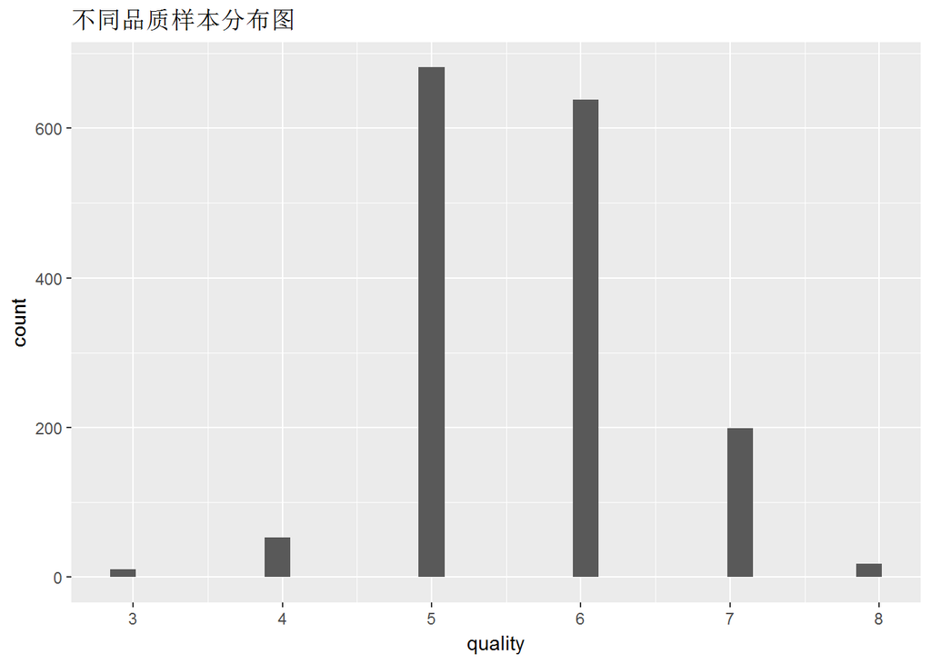

### 2. 非挥发性酸

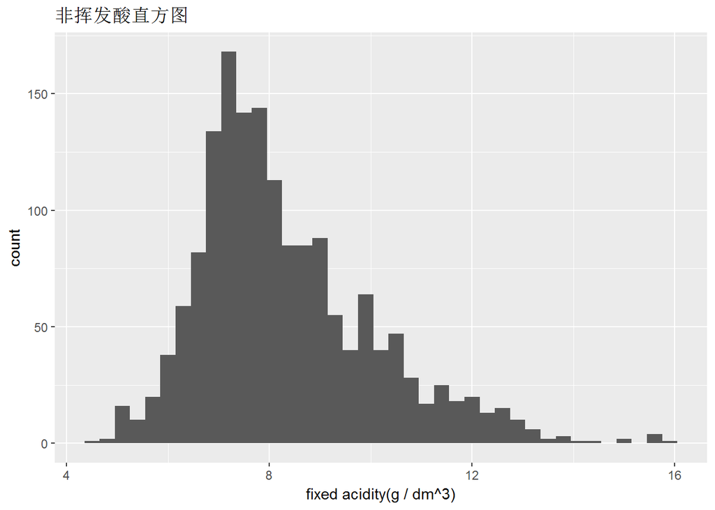

### 3. 易挥发酸性酸的分布出现双峰形态，分别在0.4和0.65处分布最多。

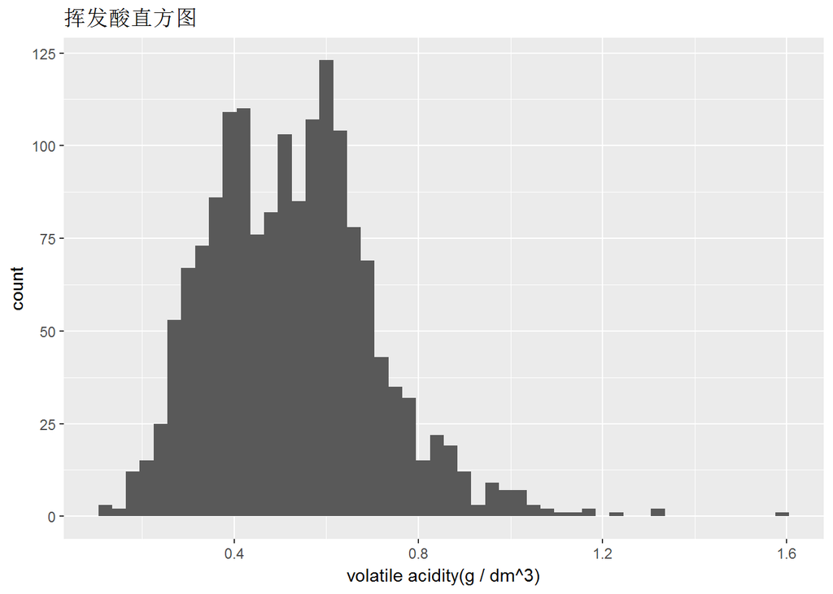

### 4. 柠檬酸的分布比较杂乱，出现了几个离群点。

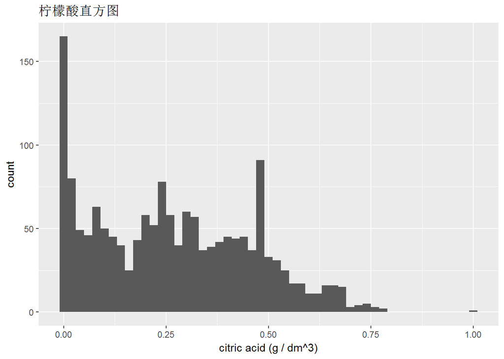

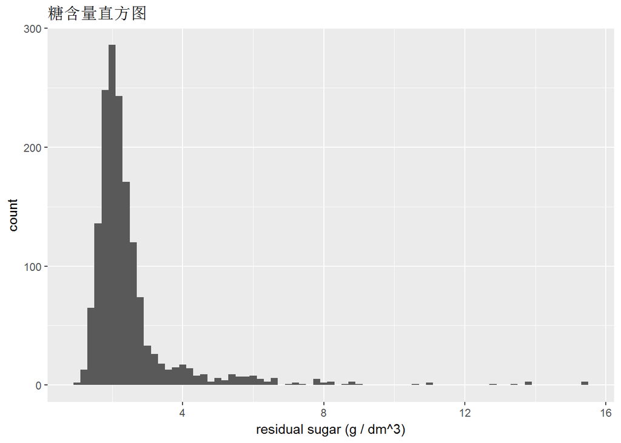

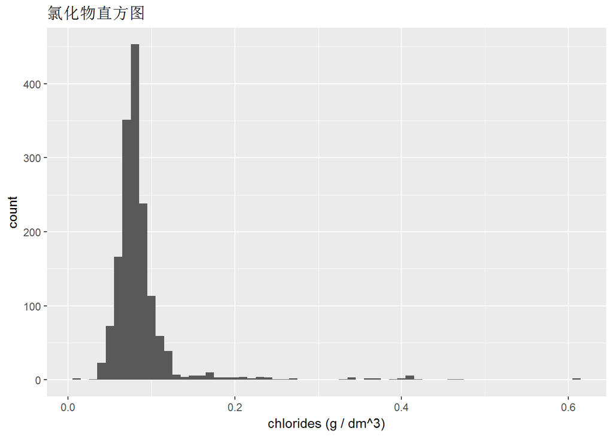

### 7. 单体硫为单调递减分布。

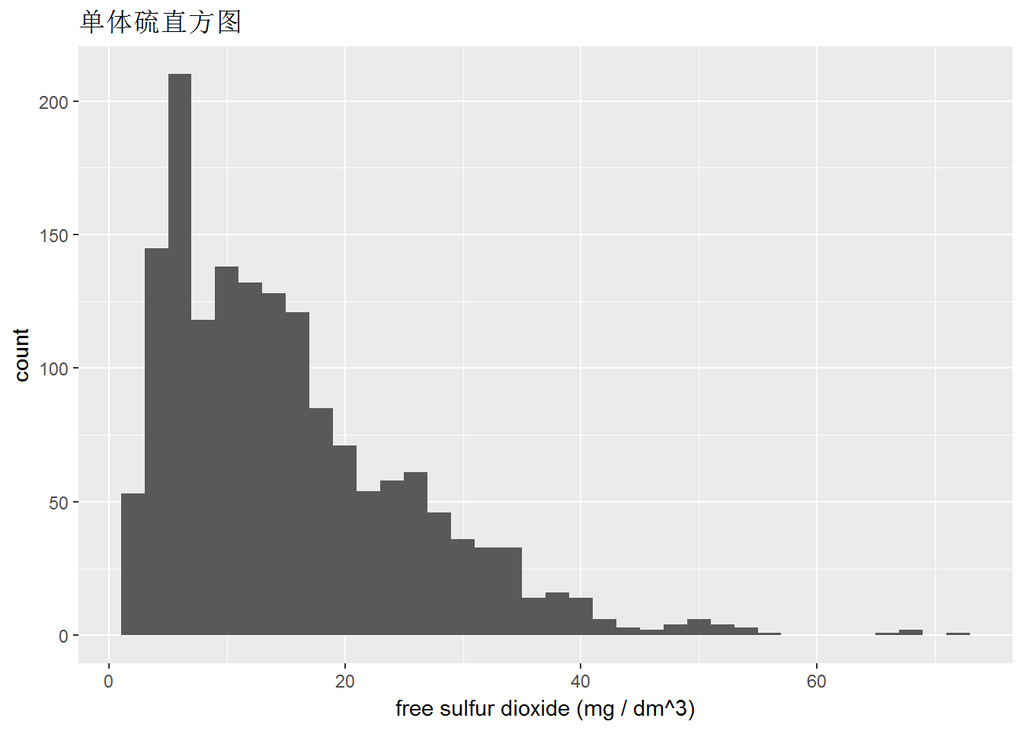

### 8. 总硫量分布为单调递减的长尾分布,对x轴取对数以后为对称分布，有少量利群点。

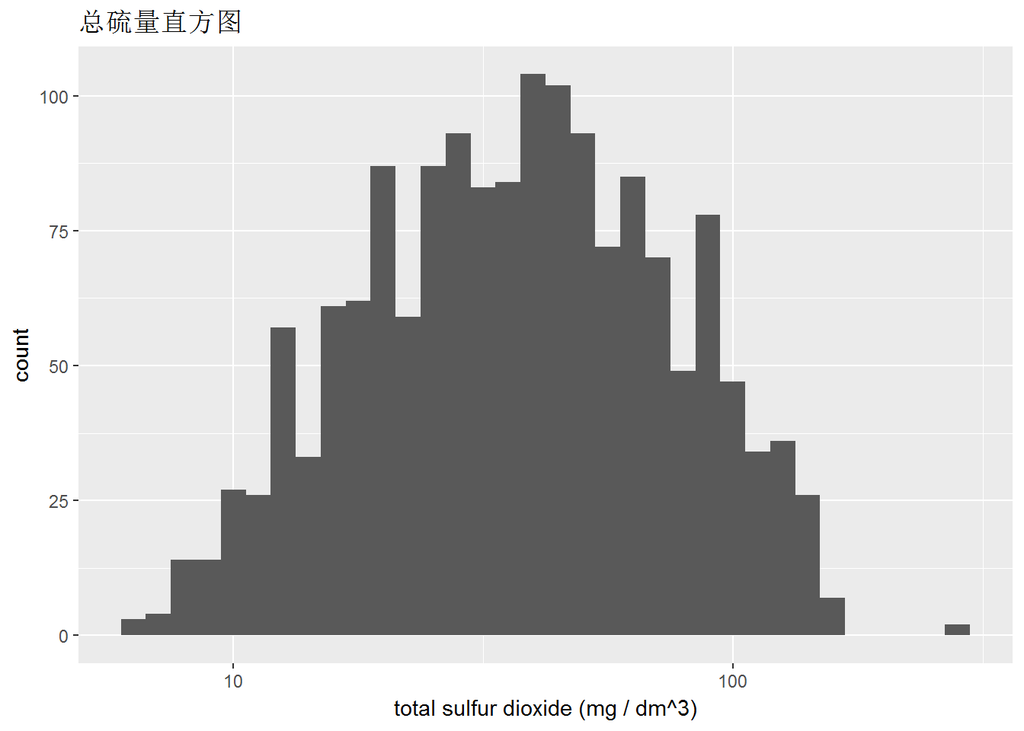

### 9. 密度为对称分布

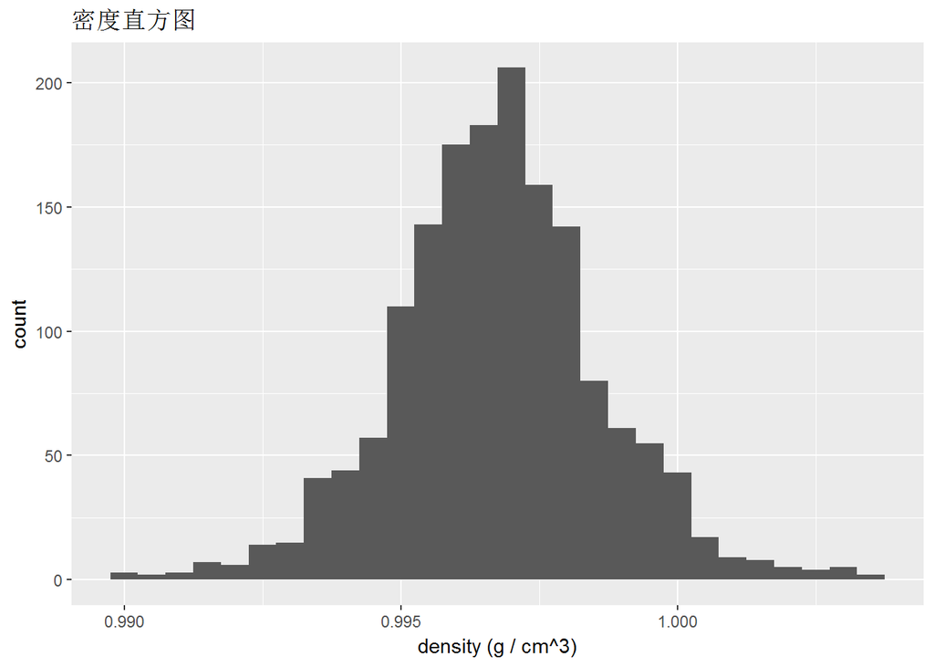

### 10. pH值几乎为对称分布

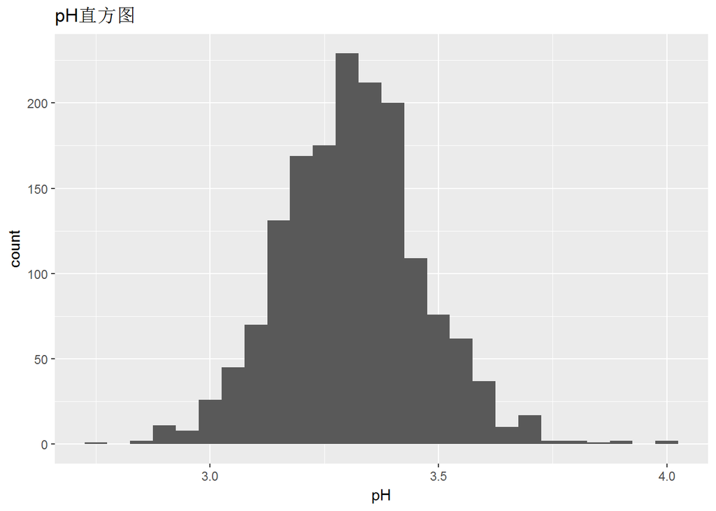

### 11. 硫酸盐对x轴取对数以后几乎为对称分布。

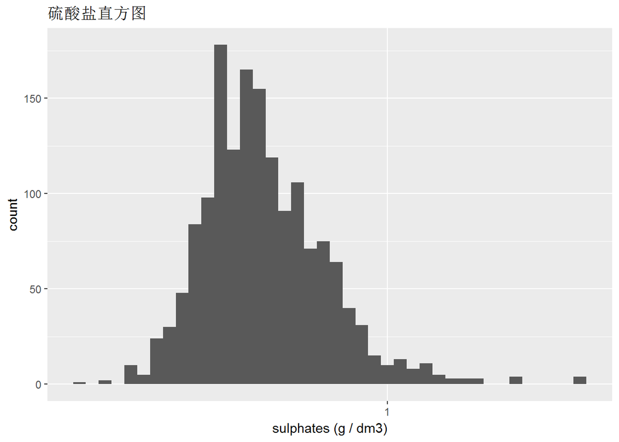

### 12. 酒精度为单调递减分布

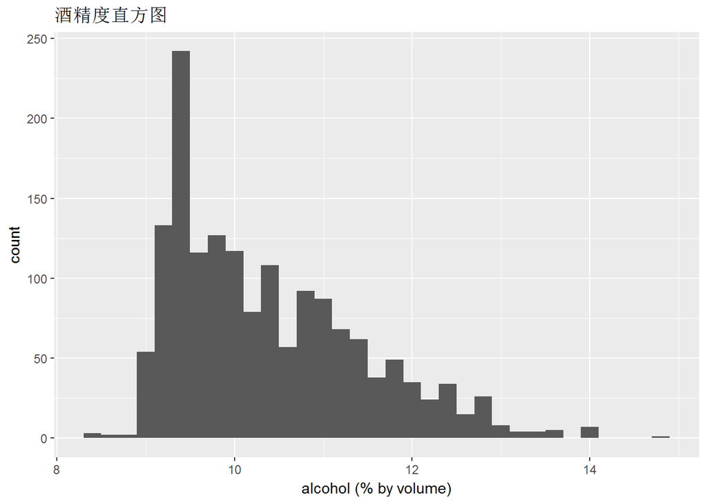

### 13. 酸总量

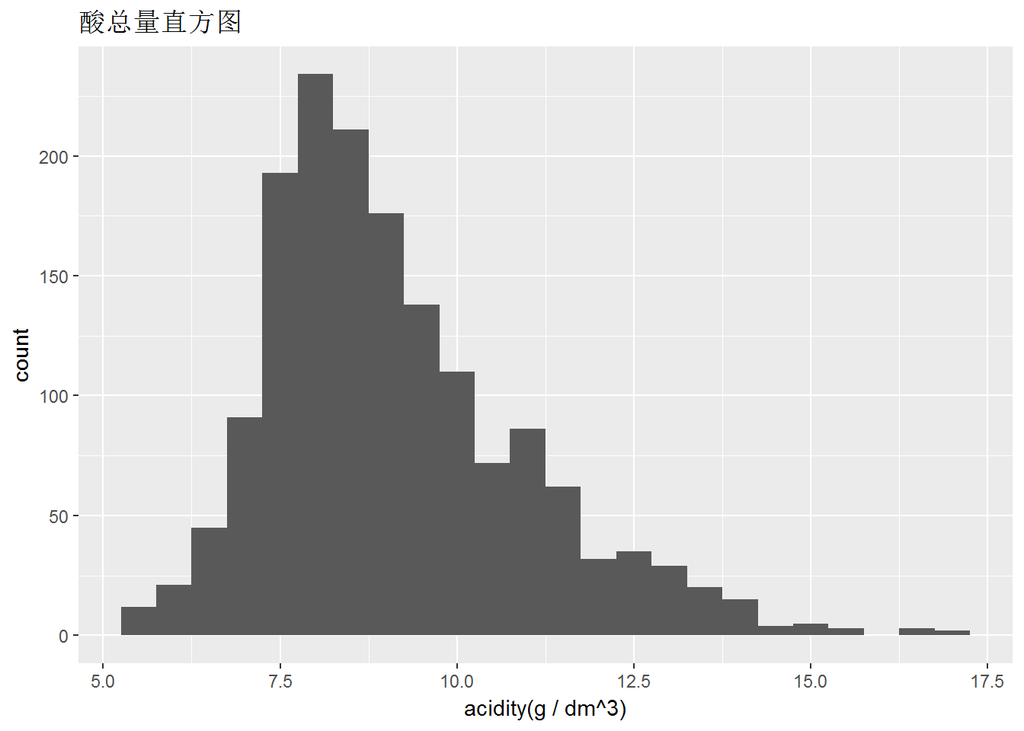

# 第二部分 总体分析

### 1. What is the structure of your dataset?

#### 数据集共有1599条样本数据，11个自变量和1个目标变量，自变量为红酒中的化学成分及其具体含量，目标变量为品酒师对酒的质量作出的评价。

### 2. What is/are the main feature(s) of interest in your dataset?

#### 我感兴趣的变量有citric.acid(柠檬酸)、free.sulfur.dioxide(游离二氧化硫)、total.sulfur.dioxide(总硫量)、alcohol(酒精度),从这些变量的的直方图可以看出，这些这些变量的分布是分布是不对称的，包含的信息较多。

### 3. What other features in the dataset do you think will help support your investigation into your feature(s) of interest?

#### 密度变量与酒的品质也有一定关系

### 4. Did you create any new variables from existing variables in the dataset?

#### 1.quality变量经过factor函数衍生出quality_factor变量 2.把所有酸加和的acidity字段

### 5. Of the features you investigated, were there any unusual distributions? Did you perform any operations on the data to tidy, adjust, or change the form of the data? If so, why did you do this?

# 第三部分 双变量图

### 2. 所有变量与quality_factor之间的boxplot

#### 非挥发性酸在5、6两种样本中低浓度占比较大，高浓度样本较少。非挥发性酸与品质之间没有很明显的关联性，3~7可以看出在均值在上升，8的均值与7相比下降，有可能是由于8的样品数量太少导致；样本分布比较分散。

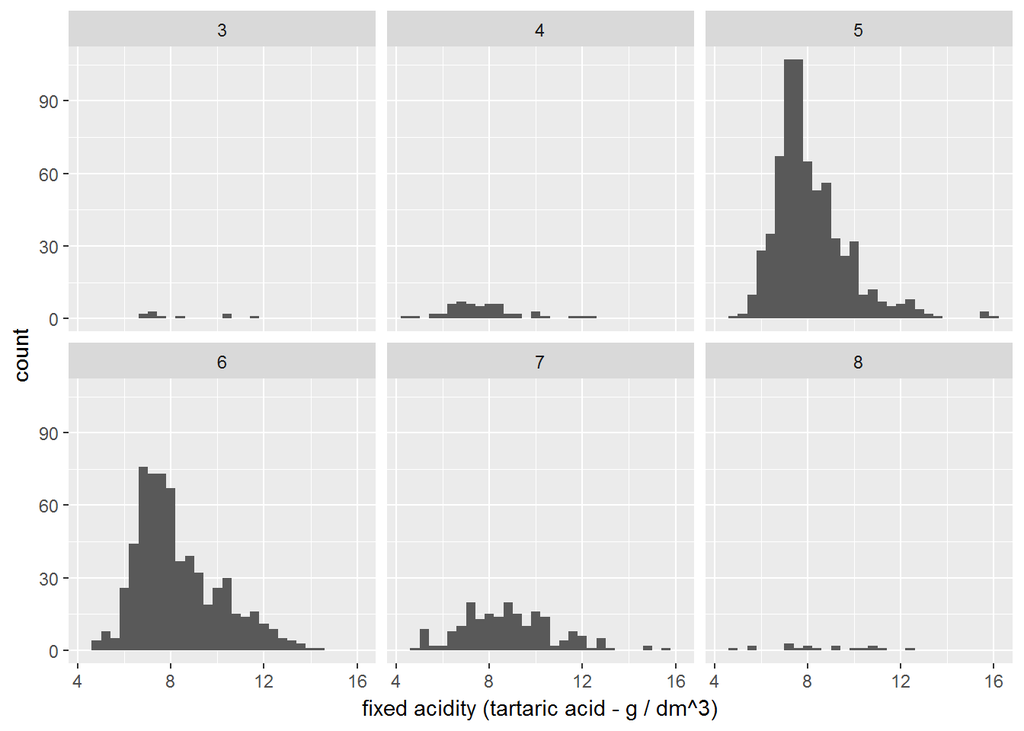

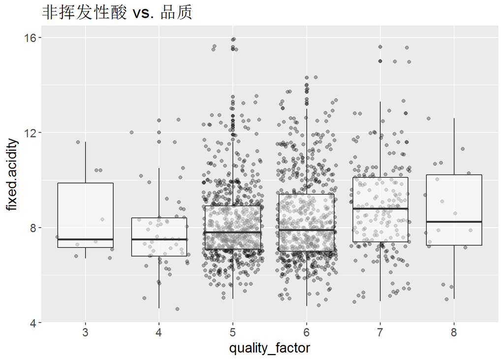

#### 3. 挥发性酸在5、6图中出现双峰分布。挥发性酸与品质之间有负相关性，挥发性酸的均值随着品质提升而下降；样本分布比较集中。

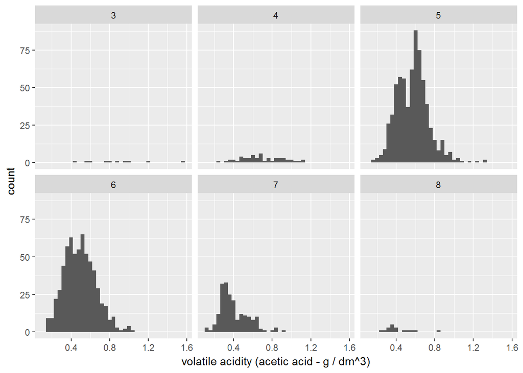

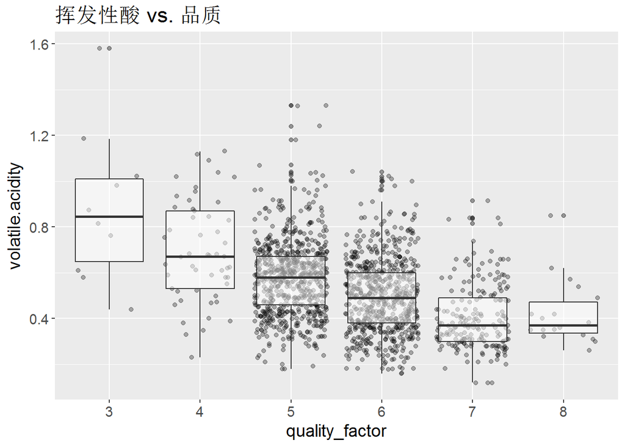

#### 4. 柠檬酸在5、6中为波动性分布。柠檬酸的均值虽然随着品质升高而上升，但是样本分布很分散，5~8的样本极大值相差不大。

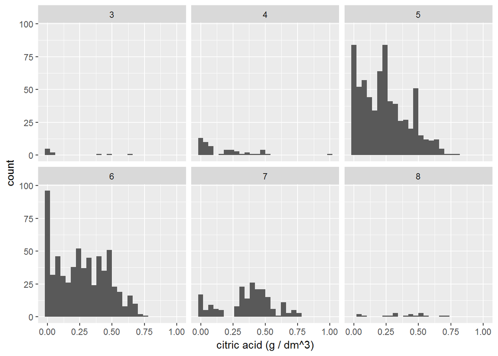

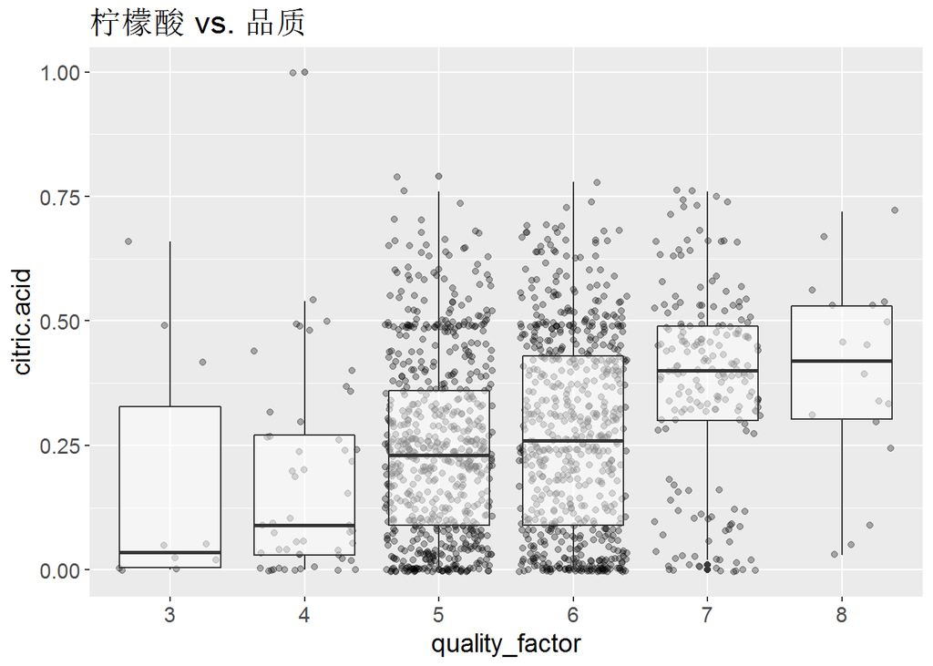

#### 5. 大部分样本分布在低浓度剩余糖区域，只有少量样本的剩余糖含量较高；剩余糖量与品质之间的相关度低，大部分样本的糖剩余量都在2左右；样本分布比较分散。

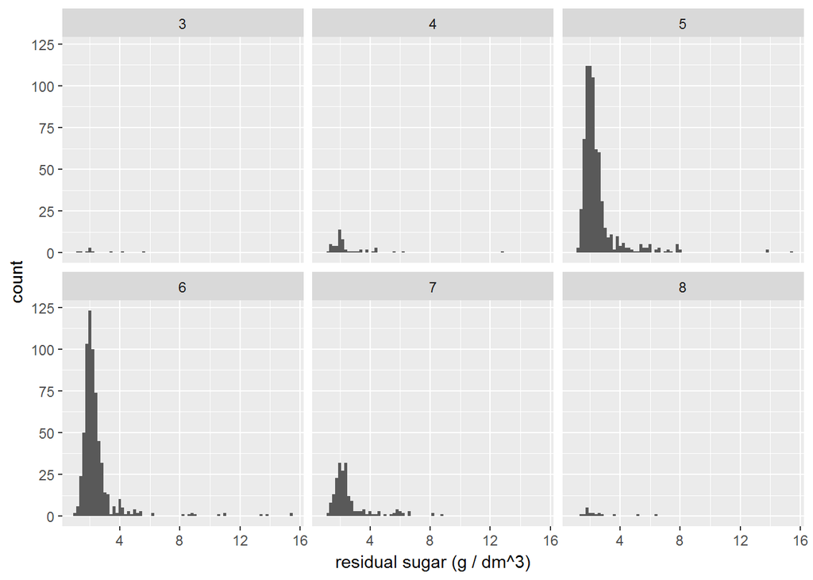

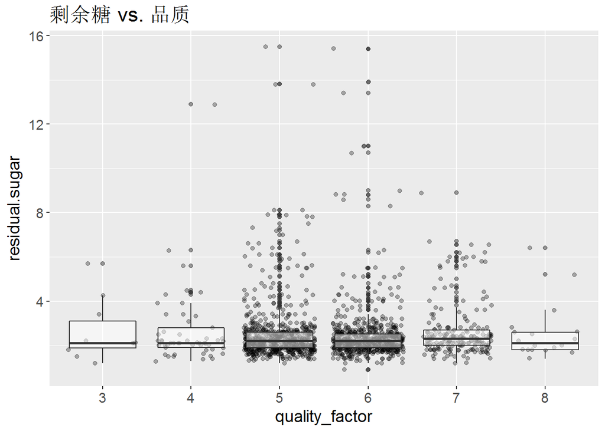

#### 6. 在x轴取对数以后，氯化物的分布为对称分布；氯化物样本分布比较集中，均值和分布情况与品质之间相关度低。

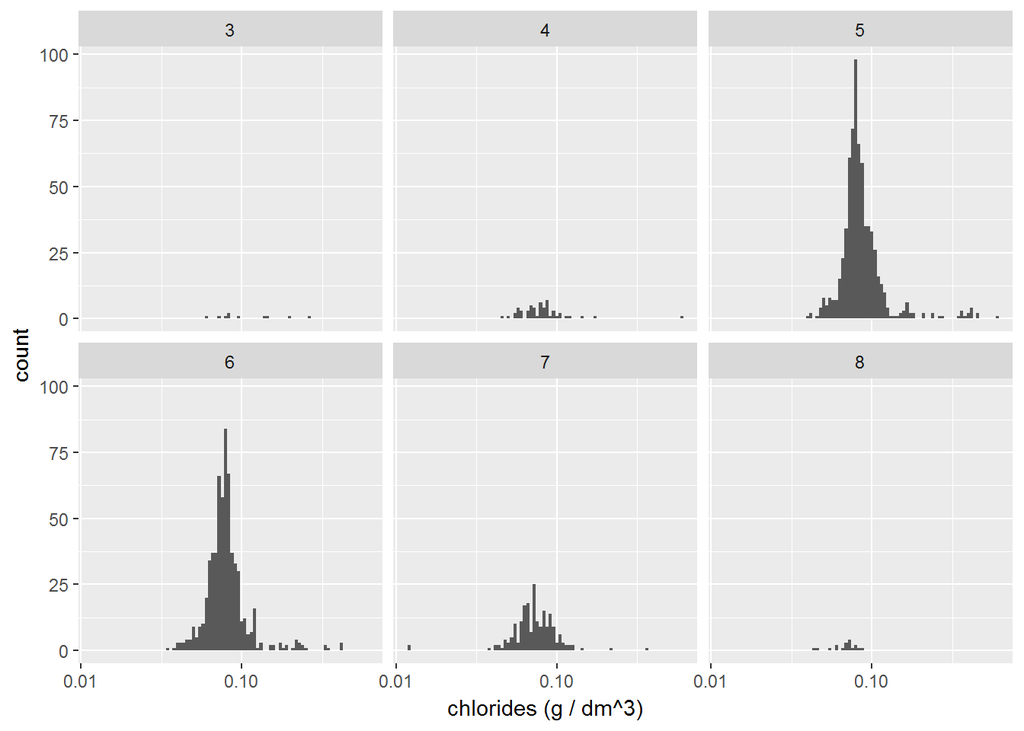

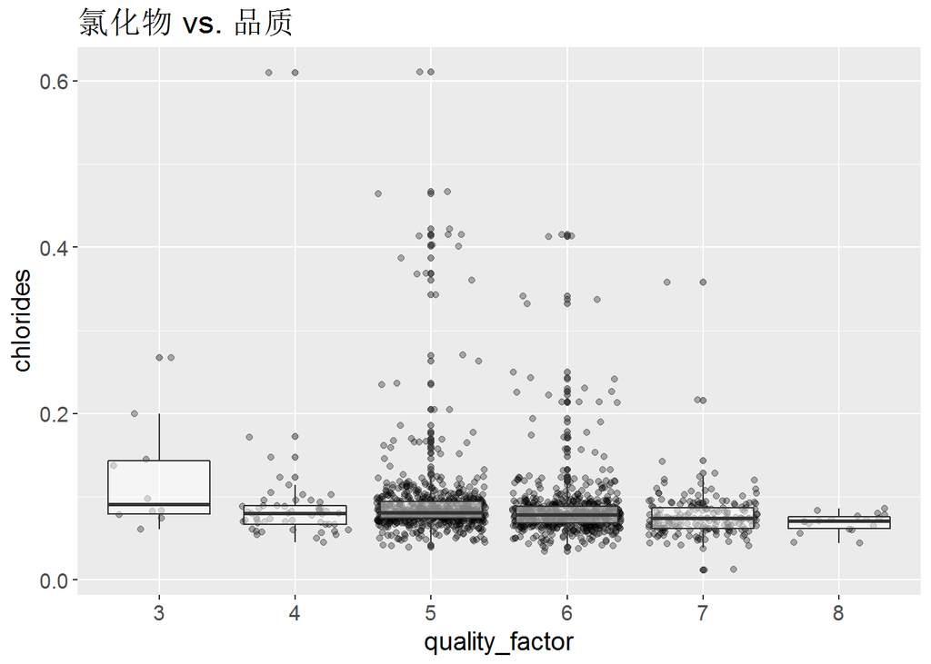

#### 7. 游离二氧化硫为单调递减分布；游离二氧化硫与品质之间呈先升高后降低的趋势。

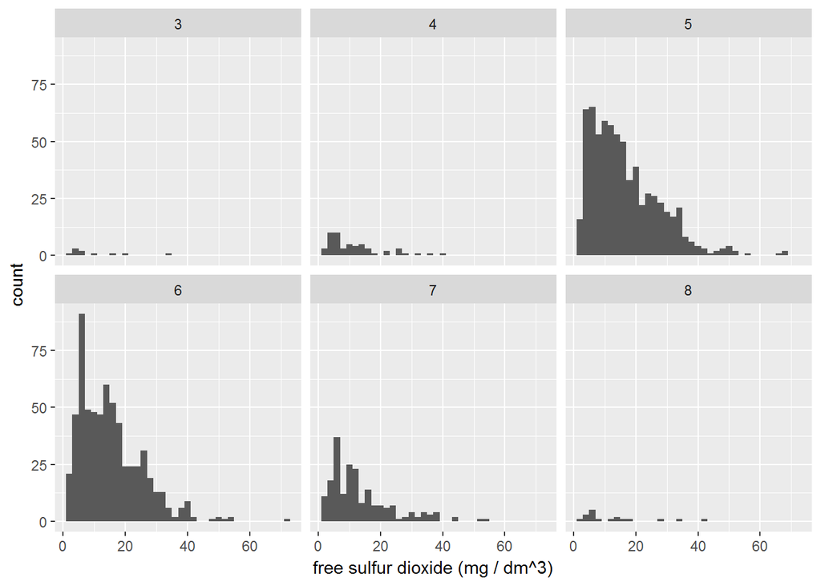

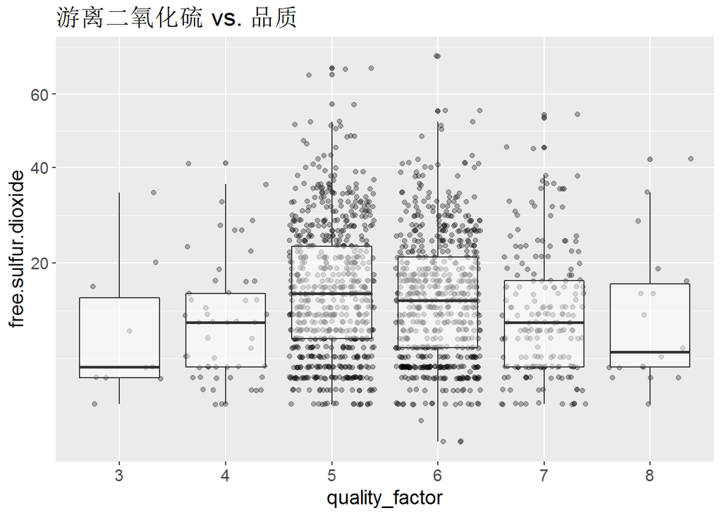

#### 8. 二氧化硫分布单调递减；二氧化硫含量与品质之间呈先上升后下降趋势。

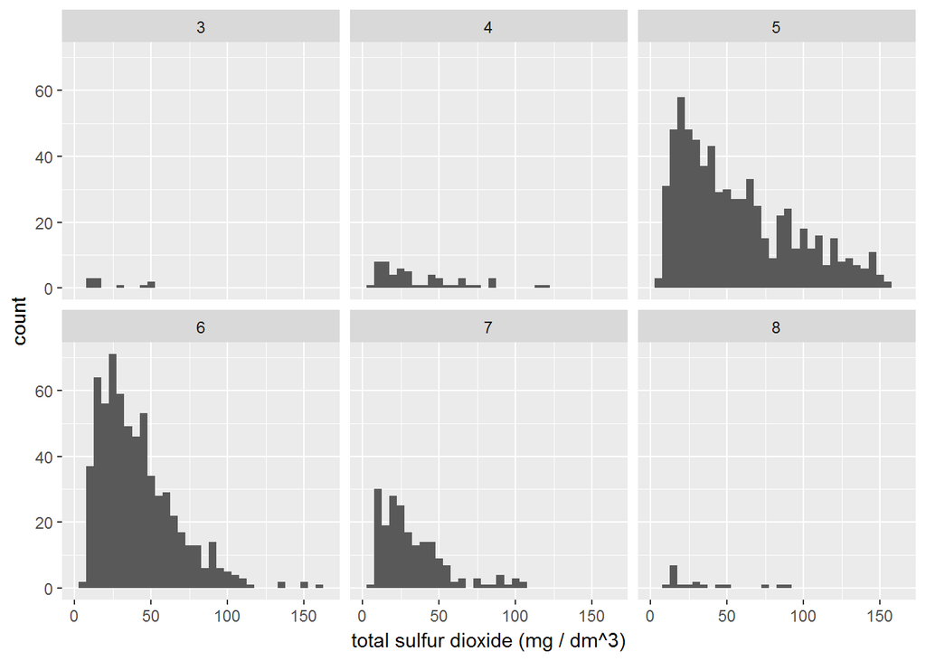

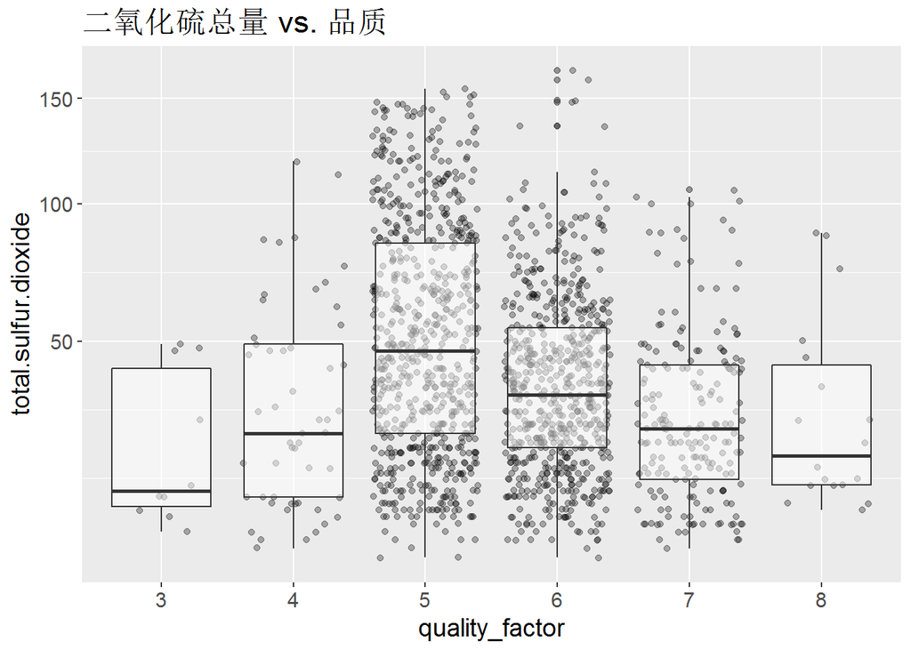

#### 9. 密度为对称分布；密度与品质之间呈下降趋势，品质越高密度越低。

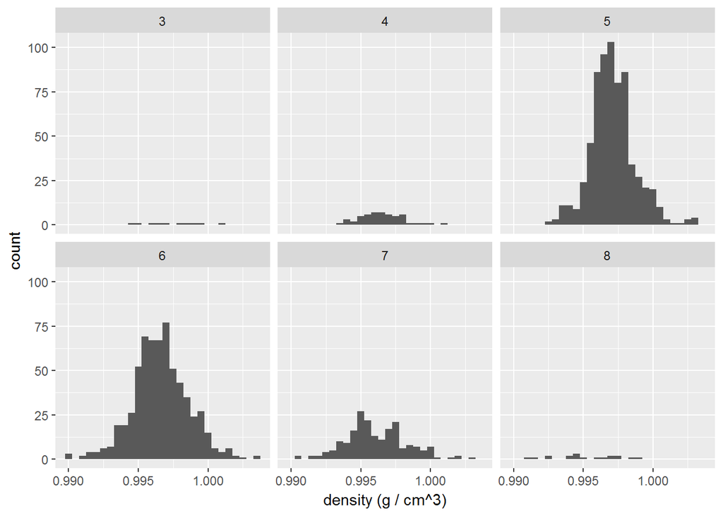

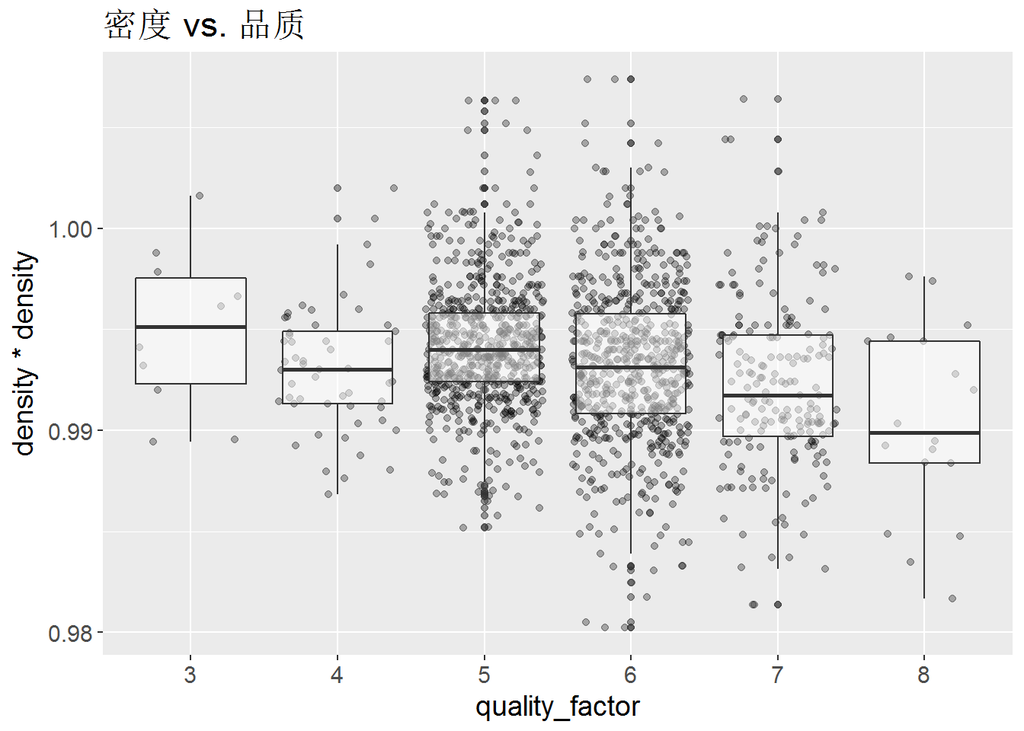

#### 10. pH为对称分布；pH与品质呈负相关性，品质越高pH值越低。

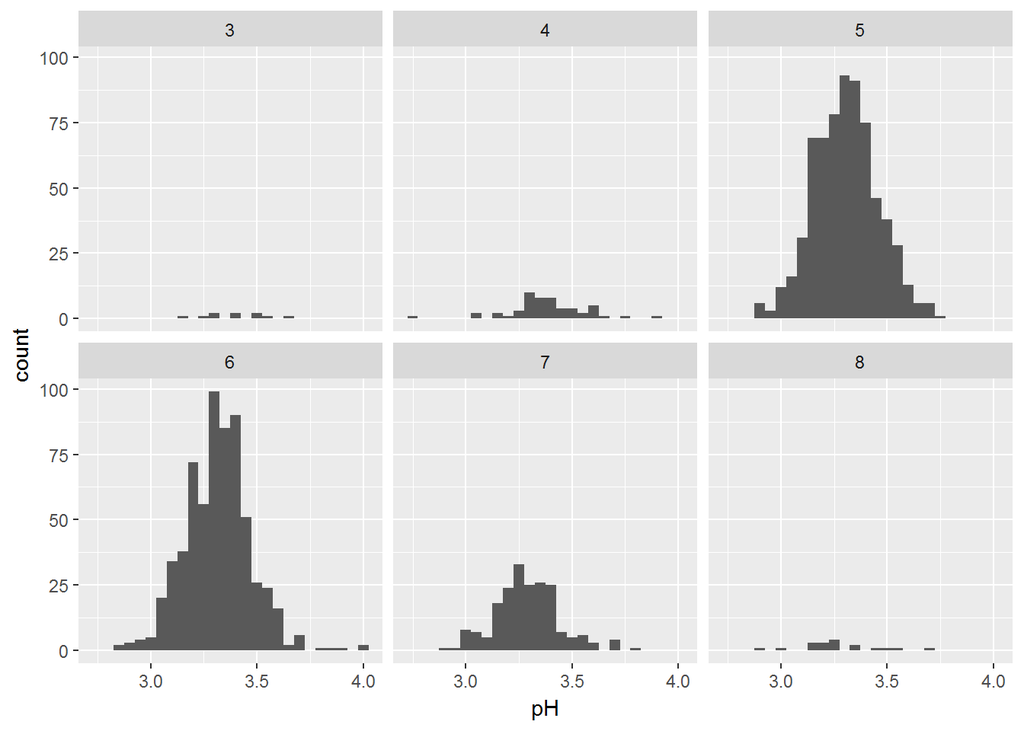

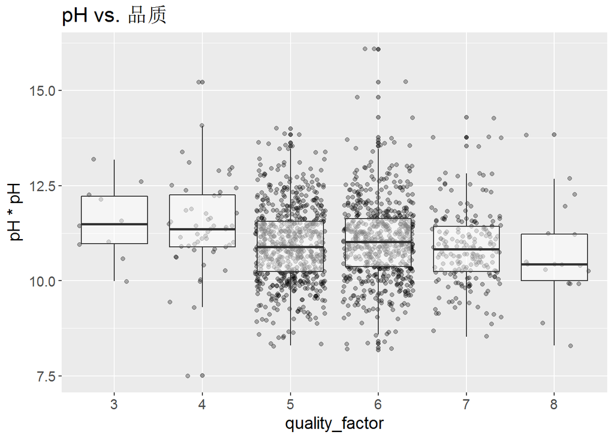